# Expression Data Analysis

Odélia Guedj

```r
library(opera)
```

# Exercice 1: Rappels de Statistiques

## Question 1

On cherche la probabilité qu’un spot correspondant à un gène exprimé possède une valeur inférieure ou égale à 700.

```r
pnorm(700,1000,100)
```

```
[1] 0.001349898
```

## Question 2

Quelle est la probabilité qu’un gène exprimé possède une expression inférieur ou égale à 700 ? Pour les details des calculs voir le fichier pdf svp.

```r
pnorm(700,1000,100/sqrt(4))
```

```
[1] 9.865876e-10
```

## Question 3

Quel est la valeur seuil t telle que la probablité d’avoir l’expression d’un gène exprimé inf´erieure ou égale à t soit égale à la probabilité d’avoir l’expression d’un gène non exprimé supérieur à t. Voir pd svp. On obtient $t^{*} = 760$

## Question 4

Quelle est la probabilité d’avoir un gène exprimé dont l’expression est inférieur à t (faux négatif)?

```r
pnorm(760,1000,100/sqrt(4))
```

```
[1] 7.933282e-07
```

## Question 5

Quelle est la probabilité d’avoir un gène non exprimé dont l’expression est supérieur à t (faux positif)?

```r
1-pnorm(760,400,150/sqrt(4))
```

```
[1] 7.933282e-07
```

## Question 6

### Simulation des données

```r
x1 = apply(matrix(rnorm(4*1000, 1000, 100),nrow = 4),2,mean)
x2 <- apply(matrix(rnorm(4*1000, 400, 150),nrow = 4),2,mean)
```

### Histogrammes

```r
xlim <- c(floor(min(x1,x2)),floor(max(x1,x2))+1)
ylim <- c(0,dnorm(1000,1000,100/sqrt(4)))
d = apply(rbind(dnorm(c(0:2000),400,150/sqrt(4)),dnorm(c(0:2000),1000,100/sqrt(4))),2,max) #la densité mélange
hist(x1,xlim = xlim,freq = F, ylim = ylim, xlab = "", ylab = "", main = "")
par(new = T)
```

```r
hist(x2,xlim = xlim,freq = F, ylim = ylim, xlab = "", ylab = "", main = "")
par(new = T)
```

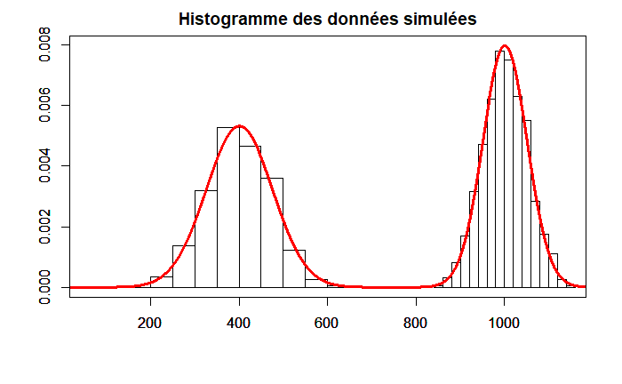

```r
plot(d, ylim = ylim, xlim = xlim, type = "l", xlab = "", ylab = "", main =
       "Histogramme des données simulées", lwd = 3, col = "red")
```

```r
hist(x1,xlim = xlim,freq = F, ylim = ylim, xlab = "", ylab = "", main = "")
par(new = T)
```

```r
hist(x2,xlim = xlim,freq = F, ylim = ylim, xlab = "", ylab = "", main = "")
par(new = T)
```

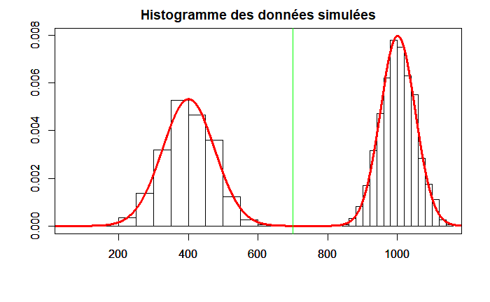

```r
plot(d, ylim = ylim, xlim = xlim, type = "l", xlab = "", ylab = "", main =
       "Histogramme des données simulées", lwd = 3, col = "red")
abline(v = 700, col = "green")
```

```r
length(which(x1<=700))
```

```
[1] 0
```

# Exercice 2: Test d’hypothèses

## Importation des données

```r
library(rda)
data(colon)
```

```r
dim(colon.x)
```

```
[1]   62 2000
```

```r
length(colon.y)
```

```
[1] 62
```

```r
colon = data.frame(colon.x, colon.y)
```

## Question 1

```r
gene1.sain = colon[colon$colon.y == 1 ,1]
gene1.malade = colon[colon$colon.y == 2 ,1]
```

### Partie a

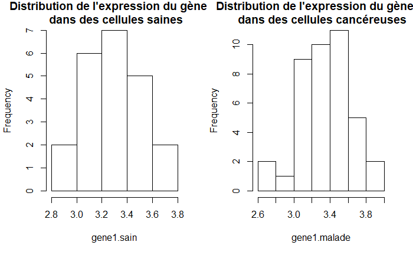

```r
par(mfrow = c(1,2))
hist(gene1.sain, main = "Distribution de l'expression du gène 1 \n dans des cellules saines")
hist(gene1.malade, main = "Distribution de l'expression du gène 1 \n dans des cellules cancéreuses")
```

Ave un teste de Student on vérifie que comme nous l’indiquent les histogrammes ci dessus, il n’y a pas de difference d’expression significative du gène 1 dans des cellules sines ou cancéreuses.

```r
test1 = t.test(gene1.sain, gene1.malade, var.equal = T)
test1
```

```
    Two Sample t-test

data:  gene1.sain and gene1.malade
t = -0.80087, df = 60, p-value = 0.4264
alternative hypothesis: true difference in means is not equal to 0
95 percent confidence interval:
 -0.19819065  0.08486261
sample estimates:
mean of x mean of y
 3.293923  3.350587
```